# Introduction to meandr

Scott McKenzie

## Why meandr?

Suppose we want to simulate the behavior of a “somewhat random” time-series phenomenon, $f(t)$.

We could use method #1 below:

```r
method_1 <- data.frame(t = 1:100,
                       f = rnorm(100))
```

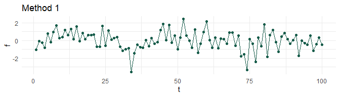

This is okay, but what if we’re feeling more adventurous?

- Outdoor temperature
- Train station crowd density
- Stock price

Using above `rnorm` method is not going to adequately illustrate the *character* of these examples.

Instead, we could wrap `rnorm` in `cumsum`:

```r
method_2 <- data.frame(t = 1:100,
                       f = cumsum(rnorm(100)))
```

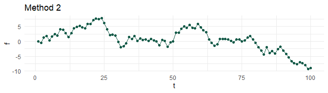

This is an improvement, but beyond this, we don’t have much control over the signal characteristics. What if we want to generate a smoother curve than above? There’s no straightforward way to extend `cumsum(rnorm())` functionality.

`meandr` offers a solution to this problem.

## Usage

Each call to `meandr()` generates a unique `tibble` of $t$ and $f$ coordinates. For reproducibility, a `seed` argument is provided.

```r
library(meandr)

df1 <- meandr(n_points = 100,
              n_nodes = 20,
              seed = 2)

df1
```

```
#> # A tibble: 100 x 2
#>         t        f
#>     <dbl>    <dbl>
#>  1 0.01   -0.00400
#>  2 0.02   -0.0160
#>  3 0.03   -0.0360
#>  4 0.04   -0.0640
#>  5 0.05   -0.100
#>  6 0.06   -0.144
#>  7 0.0700 -0.196
#>  8 0.08   -0.256
#>  9 0.09   -0.324
#> 10 0.10   -0.400
#> # ... with 90 more rows
```

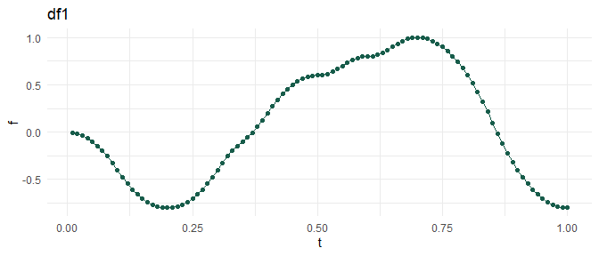

Observe `df1` curve trajectory never radically changes between two points. This is a key feature of `meandr`: $f(t)$ is *continuously differentiable*.

### Acheiving desired curve

#### 1. n_nodes

In general, modulating `n_nodes` should provide sufficient control. Here, the *nodes* correspond to inflection points.

Holding `seed` constant at `2`, observe that increasing `n_nodes` allows below function to **meander** into new territory. In other words, `df2` is just an augmented variation of `df1`.

```r
df2 <- meandr(n_points = 100,
              n_nodes = 100, # increased from 20
              wt = c(1, -1),
              seed = 2) # same seed as df1
```

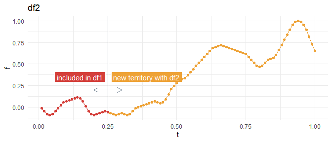

#### 2. n_points

Use `n_points` to adjust output resolution. This does not affect underlying calculus driving curve shape. Example below uses same seed `2` as before.

```r
res1 <- meandr(n_points = 10, # low resolution
               n_nodes = 100,
               seed = 2)

res2 <- meandr(n_points = 1000, # high resolution
               n_nodes = 100,
               seed = 2)
```

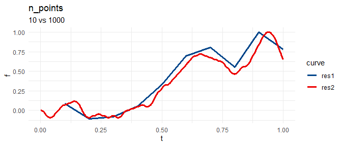

#### 3. wt & gain

Each call to `meandr` first constructs a piecewise step-function by sampling elements from input `wt`. The resulting step-function serves as the 2nd derivative, $f''(t)$, which `meandr` integrates twice to obtain final result.

This complete procedure is shown below:

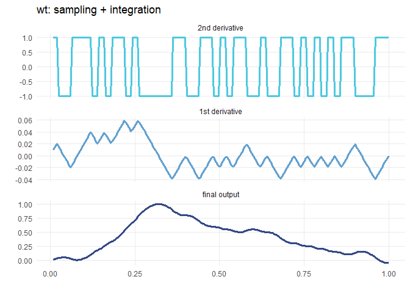

```r
meandr(n_points = 200,
       n_nodes = 50,
       wt = c(-1, 1), # default value
       seed = 1010)
```

The `wt` sampling forming $f''(t)$ utilizes a special algorithm that strives for alternating positive & negative values. This is to prevent `meandr` from generating “boring” curves.

Increasing input `gain` will increase the sensitivity of the `wt` sampling algorithm, ultimately resulting in a curve with greater local variation. Note, however, that the local effects of changing `gain` will cascade with increasing $t$, resulting in an altogether different curve for the same `seed`.

```r
gain1 <- meandr(n_points = 200,
                n_nodes = 50,
                gain = 0.75, # default
                seed = 1010)

gain2 <- meandr(n_points = 200,
                n_nodes = 50,
                gain = 2, # increase, this will inject more variance into 2nd derivative
                seed = 1010)
```

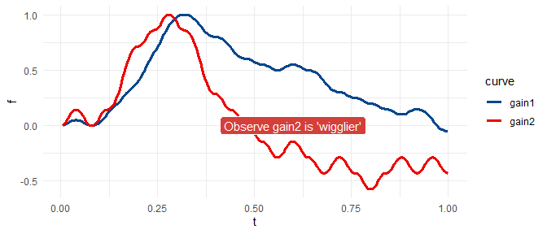

The default value of `wt`, `c(1, -1)`, is appropriate for lower levels of `gain` near `0.75`. However, `gain2` curve above looks slightly unnatural, as one can clearly tell this is simply a series of pure quadratic polynomials chained together. We can avoid this effect by adjusting `wt`.

```r
custom_wt <- meandr(n_points = 200,
                    n_nodes = 50,
                    wt = seq(-1, 1, by = 0.01), # more variety in 2nd derivative values
                    gain = 2,
                    seed = 1010)
```

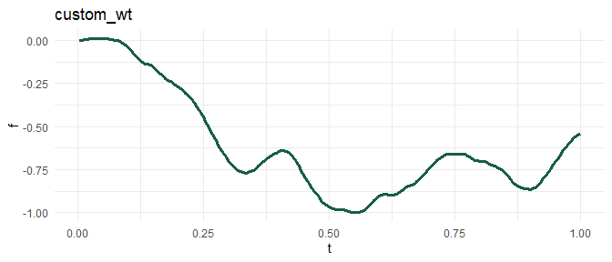

**Beware!** The `wt` algorithm passes `gain` to `exp()`, so you won’t observe much difference as $e^{gain} \rightarrow \infty$. I recommend starting at the default value of `0.75` and making incremental adjustments as needed.

```r
gain3 <- meandr(gain = 1000) # 1000 doesn't work because exp(1000) returns Inf
```

```
#> Error in sample.int(length(x), size, replace, prob): NA in probability vector
```

#### 4. scale

`meandr` will adjust output so that $max(f) = scale$.

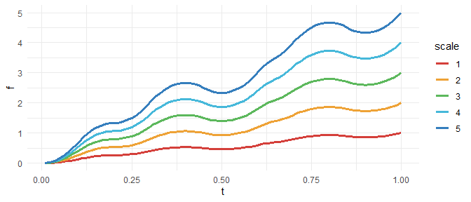

```r
library(purrr)

scale <- map_dfr(1:5, ~ {
  meandr(n_points = 100,
         n_nodes = 20,
         wt = c(1, -1),
         scale = .x,
         seed = 20) %>%
    mutate(scale = .x)
})
```

This is useful if you want to supplement `meandr` curve with additional noise. In example below, relative amplitude of noise is consistent across different `meandr` curves because we use fixed `scale`.

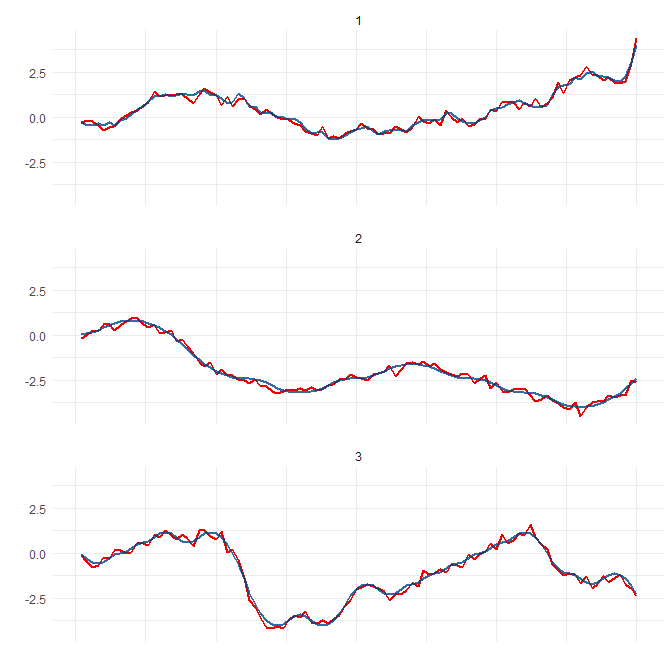

```r
library(dplyr)

meandr(scale = 4) %>%
  mutate(with_noise = f + rnorm(100, sd = 0.2))
```